# Iris Dataset EDA

Exploratory Data Analysis on the Iris dataset using Pandas, NumPy, Matplotlib, and Seaborn.

```python
import pandas as pd
import numpy as np
import matplotlib.pyplot as plt
import seaborn as sns
%matplotlib inline
```

## Loading the Dataset

```python
df = pd.read_csv('iris.csv', names=['sepal_length', 'sepal_width', 'petal_length', 'petal_width', 'species'])
```

```python
#Checking first few rows
df.head()
```

|  | sepal_length | sepal_width | petal_length | petal_width | species |
| --- | --- | --- | --- | --- | --- |
| 0 | 5.1 | 3.5 | 1.4 | 0.2 | Iris-setosa |
| 1 | 4.9 | 3.0 | 1.4 | 0.2 | Iris-setosa |
| 2 | 4.7 | 3.2 | 1.3 | 0.2 | Iris-setosa |
| 3 | 4.6 | 3.1 | 1.5 | 0.2 | Iris-setosa |
| 4 | 5.0 | 3.6 | 1.4 | 0.2 | Iris-setosa |

## Basic data Exploration

```python
#Check the dataset structure
df.info()
```

```
<class 'pandas.core.frame.DataFrame'>
RangeIndex: 150 entries, 0 to 149
Data columns (total 5 columns):
 #   Column        Non-Null Count  Dtype
---  ------        --------------  -----
 0   sepal_length  150 non-null    float64
 1   sepal_width   150 non-null    float64
 2   petal_length  150 non-null    float64
 3   petal_width   150 non-null    float64
 4   species       150 non-null    object
dtypes: float64(4), object(1)
memory usage: 6.0+ KB
```

```python
#View first few rows
df.head
```

```
<bound method NDFrame.head of      sepal_length  sepal_width  petal_length  petal_width         species
0             5.1          3.5           1.4          0.2     Iris-setosa
1             4.9          3.0           1.4          0.2     Iris-setosa
2             4.7          3.2           1.3          0.2     Iris-setosa
3             4.6          3.1           1.5          0.2     Iris-setosa
4             5.0          3.6           1.4          0.2     Iris-setosa
..            ...          ...           ...          ...             ...
145           6.7          3.0           5.2          2.3  Iris-virginica
146           6.3          2.5           5.0          1.9  Iris-virginica
147           6.5          3.0           5.2          2.0  Iris-virginica
148           6.2          3.4           5.4          2.3  Iris-virginica
149           5.9          3.0           5.1          1.8  Iris-virginica

[150 rows x 5 columns]>
```

```python
df.head()
```

|  | sepal_length | sepal_width | petal_length | petal_width | species |
| --- | --- | --- | --- | --- | --- |
| 0 | 5.1 | 3.5 | 1.4 | 0.2 | Iris-setosa |
| 1 | 4.9 | 3.0 | 1.4 | 0.2 | Iris-setosa |
| 2 | 4.7 | 3.2 | 1.3 | 0.2 | Iris-setosa |
| 3 | 4.6 | 3.1 | 1.5 | 0.2 | Iris-setosa |
| 4 | 5.0 | 3.6 | 1.4 | 0.2 | Iris-setosa |

```python
#Calculate summary statistics for numerical columns
df.describe()
```

|  | sepal_length | sepal_width | petal_length | petal_width |
| --- | --- | --- | --- | --- |
| count | 150.000000 | 150.000000 | 150.000000 | 150.000000 |
| mean | 5.843333 | 3.054000 | 3.758667 | 1.198667 |
| std | 0.828066 | 0.433594 | 1.764420 | 0.763161 |
| min | 4.300000 | 2.000000 | 1.000000 | 0.100000 |
| 25% | 5.100000 | 2.800000 | 1.600000 | 0.300000 |
| 50% | 5.800000 | 3.000000 | 4.350000 | 1.300000 |
| 75% | 6.400000 | 3.300000 | 5.100000 | 1.800000 |
| max | 7.900000 | 4.400000 | 6.900000 | 2.500000 |

```python
#Check for missing values to ensure data quality
df.isnull()
```

|  | sepal_length | sepal_width | petal_length | petal_width | species |
| --- | --- | --- | --- | --- | --- |
| 0 | False | False | False | False | False |
| 1 | False | False | False | False | False |
| 2 | False | False | False | False | False |
| 3 | False | False | False | False | False |
| 4 | False | False | False | False | False |
| ... | ... | ... | ... | ... | ... |
| 145 | False | False | False | False | False |
| 146 | False | False | False | False | False |
| 147 | False | False | False | False | False |
| 148 | False | False | False | False | False |
| 149 | False | False | False | False | False |

150 rows × 5 columns

## Feature Distributions

Histograms with KDE for sepal_length, sepal_width, petal_length, and petal_width to visualize their distributions.

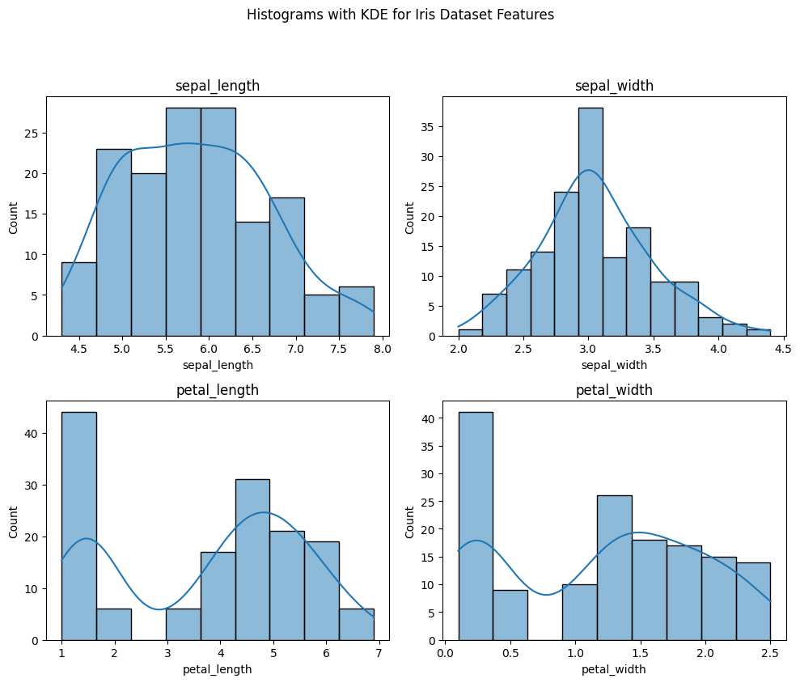

```python
# Create a 2x2 subplot grid
fig, axes = plt.subplots(2, 2, figsize=(10, 8))

# List of numerical features
features = ['sepal_length', 'sepal_width', 'petal_length', 'petal_width']

# Flatten axes for easier iteration
axes = axes.flatten()

# Loop through the features and plot histogram with KDE
for i, feature in enumerate(features):
    sns.histplot(data=df, x=feature, kde=True, ax=axes[i])
    axes[i].set_title(feature)

# Add a figure description
fig.suptitle('Histograms with KDE for Iris Dataset Features', y=1.05)

# Adjust layout to prevent overlap
plt.tight_layout()

# Save the plot with alt text metadata
plt.savefig('feature_distributions.png', metadata={'alt': 'Histograms with KDE showing the distribution of sepal length, sepal width, petal length, and petal width across all Iris samples.'})

# Display the plot
plt.show()
```

## Correlation Analysis

Heatmap of correlations between numerical features to identify realtionships

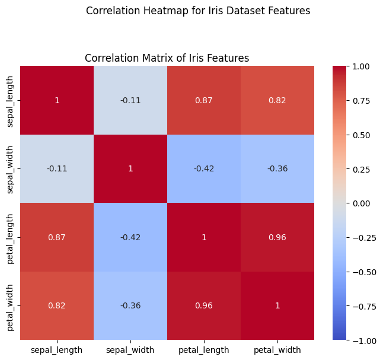

```python
# Compute the correlation matrix for numerical features
corr_matrix = df.corr(numeric_only=True)

# Create a heatmap to visualize correlations
plt.figure(figsize=(8, 6))
sns.heatmap(corr_matrix, annot=True, cmap='coolwarm', vmin=-1, vmax=1)
plt.title('Correlation Matrix of Iris Features')

# Add a figure description
plt.suptitle('Correlation Heatmap for Iris Dataset Features', y=1.05)

# Save the plot with alt text metadata
plt.savefig('correlation_matrix.png', metadata={'alt': 'Correlation heatmap showing Pearson correlations between sepal length, sepal width, petal length, and petal width in the Iris dataset.'})

# Display the plot
plt.show()
```

## Feature Relationships

Pairplot of numerical features colored by species to explore relationships and species separation

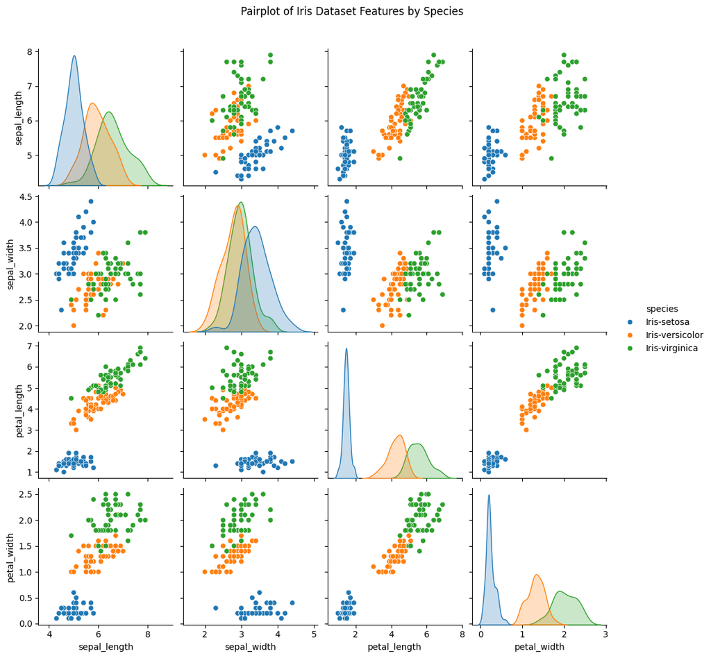

```python
# Create a pairplot colored by species
g = sns.pairplot(df, hue='species')

# Add a figure description
g.fig.suptitle('Pairplot of Iris Dataset Features by Species', y=1.05)

# Save the plot with alt text metadata
g.savefig('pairplot.png', metadata={'alt': 'Pairplot showing scatter plots and histograms of sepal length, sepal width, petal length, and petal width, colored by Iris species (setosa, versicolor, virginica).'})

# Display the plot
plt.show()
```

## Features Comparison Across Species

Box plots of numericall features to compare distributions across Iris-setosa, Iris-versicolor, and Iris-virginica.

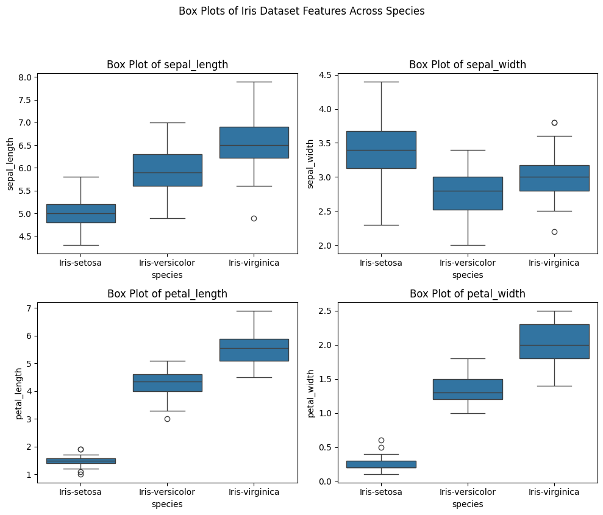

```python
# Create a 2x2 subplot grid
fig, axes = plt.subplots(2, 2, figsize=(10, 8))

# List of numerical features
features = ['sepal_length', 'sepal_width', 'petal_length', 'petal_width']

# Flatten axes for easier iteration
axes = axes.flatten()

# Loop through features and plot box plots
for i, feature in enumerate(features):
    sns.boxplot(data=df, x='species', y=feature, ax=axes[i])
    axes[i].set_title(f'Box Plot of {feature}')

# Add a figure description
fig.suptitle('Box Plots of Iris Dataset Features Across Species', y=1.05)

# Adjust layout to prevent overlap
plt.tight_layout()

# Save the plot with alt text metadata
plt.savefig('box_plots.png', metadata={'alt': 'Box plots showing the distribution of sepal length, sepal width, petal length, and petal width across Iris species (setosa, versicolor, virginica).'})

# Display the plot
plt.show()
```

## Violin Plots

Violin plots of numerical feature to show distribution and density across Iris-setosa, Iris-versicolor, and Iris-virginica.

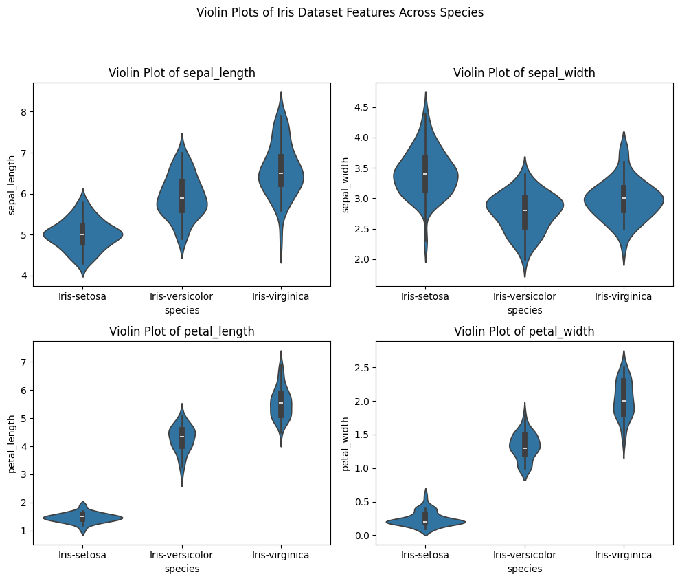

```python
# Create a 2x2 subplot grid
fig, axes = plt.subplots(2, 2, figsize=(10, 8))

# List of numerical features
features = ['sepal_length', 'sepal_width', 'petal_length', 'petal_width']

# Flatten axes for easier iteration
axes = axes.flatten()

# Loop through features and plot violin plots
for i, feature in enumerate(features):
    sns.violinplot(data=df, x='species', y=feature, ax=axes[i])
    axes[i].set_title(f'Violin Plot of {feature}')

# Add a figure description
fig.suptitle('Violin Plots of Iris Dataset Features Across Species', y=1.05)

# Adjust layout to prevent overlap
plt.tight_layout()

# Save the plot with alt text metadata
plt.savefig('violin_plots.png', metadata={'alt': 'Violin plots showing the density and distribution of sepal length, sepal width, petal length, and petal width across Iris species (setosa, versicolor, virginica).'})

# Display the plot
plt.show()
```

## Summary of Findings

The Iris dataset, with its 150 samples across three species (`Iris-setosa`, `Iris-versicolor`, and `Iris-virginica`), provides a rich foundation for exploratory data analysis. Through a series of visualizations—histograms, correlation heatmaps, pairplots, box plots, and violin plots—I’ve uncovered distinct patterns in the numerical features (`sepal_length`, `sepal_width`, `petal_length`, `petal_width`) and their relationships with species. Below is a refined summary of the insights gained, highlighting the nuances of each feature and their implications for species classification.

### Feature Distributions

The initial exploration of feature distributions revealed significant differences across the Iris species. Petal length and petal width exhibit striking bimodal distributions, reflecting the inherent separation between species. For petal length, the distribution peaks at approximately 1.5 cm for Iris-setosa, while a second peak emerges around 4.5–5.5 cm for Iris-versicolor and Iris-virginica combined. Similarly, petal width peaks at 0.2 cm for setosa and around 1.5–2.0 cm for the other two species. These bimodal patterns underscore the potential of petal measurements as discriminative features. In contrast, sepal length and sepal width display more unimodal distributions, with sepal length centered around 5.5–6.5 cm and sepal width around 3.0–3.5 cm, though subtle variations across species are evident upon closer inspection.

### Feature Relationships via Pairplot

The pairplot provided a comprehensive view of feature relationships, with scatter plots colored by species revealing clear clusters. Petal length and petal width emerged as the most discriminative features: Iris-setosa forms a tight cluster with petal lengths of 1.0–2.0 cm and petal widths of 0.1–0.5 cm, while Iris-versicolor and Iris-virginica occupy larger ranges (3.0–5.0 cm and 5.0–7.0 cm for petal length, respectively; 1.0–1.8 cm and 1.5–2.5 cm for petal width). Notably, versicolor and virginica show some overlap in these features, but setosa remains distinctly separated. Sepal measurements, however, present more overlap: sepal length ranges from 4.5–5.5 cm for setosa, 5.0–7.0 cm for versicolor, and 5.5–8.0 cm for virginica, while sepal width shows even less distinction, with setosa averaging slightly wider (3.0–4.0 cm) compared to versicolor and virginica (2.5–3.5 cm). These findings reinforce the dominance of petal features in species classification.

### Box Plots: Comparing Features Across Species

Box plots further confirmed the trends observed in the pairplot, providing a statistical summary of feature distributions across species. For petal length, Iris-setosa has a median of 1.5 cm, with a tight interquartile range (IQR) of 1.4–1.6 cm, while versicolor’s median is 4.3 cm (IQR: 4.0–4.6 cm) and virginica’s is 5.5 cm (IQR: 5.1–5.9 cm). Petal width follows a similar pattern, with medians of 0.2 cm (setosa), 1.3 cm (versicolor), and 2.0 cm (virginica), and minimal overlap between species. Sepal length shows a progressive increase across species—medians of 5.0 cm (setosa), 5.9 cm (versicolor), and 6.5 cm (virginica)—but with more overlap in the IQRs. Sepal width, however, exhibits significant overlap, with medians of 3.4 cm (setosa), 2.8 cm (versicolor), and 3.0 cm (virginica), and a few outliers in virginica extending beyond 3.5 cm. These box plots highlight the consistency of petal features in distinguishing species, while sepal features offer less clarity.

### Violin Plots: Density and Distribution Insights

The violin plots enriched this analysis by combining distribution density with box plot statistics, offering a deeper perspective on feature variability. For petal length, Iris-setosa’s distribution is tightly concentrated around 1.5 cm, with a narrow violin shape, while versicolor’s distribution widens (3.0–5.0 cm) and virginica’s is even broader (4.5–7.0 cm), reflecting greater variability within the species. Petal width mirrors this pattern: setosa’s violin is slim at 0.1–0.5 cm, versicolor’s spans 1.0–1.8 cm, and virginica’s extends from 1.5–2.5 cm, with a thicker density around 2.0 cm. Sepal length shows a gradual increase across species, with setosa’s density peaking at 4.5–5.5 cm, versicolor’s at 5.0–7.0 cm, and virginica’s at 5.5–8.0 cm, though overlap remains notable. Sepal width violins reveal setosa’s wider distribution (3.0–4.0 cm) compared to versicolor and virginica (both ~2.5–3.5 cm), with virginica showing a slightly denser peak at 3.0 cm. The violin plots underscore the distinctiveness of petal features and the nuanced variability in sepal measurements.

### Overall Insights

This exploratory analysis of the Iris dataset reveals that petal length and petal width are the most robust features for species classification, consistently showing clear separation across Iris-setosa, Iris-versicolor, and Iris-virginica, alongside a strong positive correlation. Their tight distributions for setosa and wider variability for virginica highlight their reliability as discriminative markers. Sepal length provides some differentiation, with a clear trend of increasing values across species, but its overlap limits its effectiveness. Sepal width, with its weaker correlations and significant overlap, appears the least discriminative, though setosa’s slightly wider sepals offer a minor distinguishing trait. These findings suggest that a classification model for the Iris dataset would likely benefit most from focusing on petal measurements, potentially supplemented by sepal length, while sepal width may require additional feature engineering to enhance its utility. This analysis not only deepens our understanding of the Iris dataset but also lays a strong foundation for predictive modeling and further statistical exploration.